# Assignment 7

Jon Brauer & Tyeisha Fordham

2022-10-01

### Assignment 7 Objectives

#### The purpose of this seventh assignment is to help you use R to complete some of the SPSS Exercises from the end of Chapter 7 in Bachman, Paternoster, & Wilson’s [Statistics for Criminology & Criminal Justice, 5th Ed](https://edge.sagepub.com/bachmansccj5e).

In the last assignment, you were introduced to frequentist empirical probabilities and probability distributions, including the standard normal (z) distribution. You also learned how these are essential to **null hypothesis significance testing**, which is the process by which most social scientists make inferences from sample descriptive statistics to population parameters. Finally, you practiced various steps in this process, such as calculating frequentist probabilities from crosstabs, calculating z-scores from raw observation values, and even conducting a basic binomial hypothesis test.

In Assignment 7, we will dig deeper into the process of making statistical inferences about population parameters from sample statistics. For instance, you will learn to think about sample descriptive statistics (e.g., a sample mean or correlation coefficient) as *point estimates* of population parameters. Moreover, while point estimates may represent our best or most likely guess about the value of a population parameter, a point estimate usually is just one among many potential estimates of a population parameter that are plausible under our data and modeling assumptions. In fact, we can use our knowledge of probability to calculate an *interval estimate*, such as a frequentist 95% **confidence interval**, around a point estimate.

Pragmatically, a confidence interval is a range of plausible estimates that quantifies the degree of uncertainty we have in our estimate of a population parameter. Learning to think about sample-derived estimates of population parameters as (uncertain) *interval estimates* rather than as (fixed and certain) *point estimates* is essential to truly understanding the process of statistical inference. After all, we rarely know the true population parameters and, thus, the seductive tendency to view sample statistics as “real” and known calculations of population values is misguided and prone to inference errors.

Unfortunately, frequentist confidence intervals (like their *p*-value cousins) are notoriously misunderstood and misinterpreted. For instance, it is quite common to read or hear people explain a 95% confidence interval like this: “We can be 95% certain that the true population parameter we seek falls within the 95% confidence interval we constructed around our sample point estimate.” Sadly, this is an inaccurate interpretation. When we calculate a frequentist 95% confidence interval, we are not 95% confident in the calculated interval itself. Rather, we are confident in the *method* that we used to generate confidence intervals.

What does this mean? Well, do you recall that long run or “sampling” notion of probability we discussed in the last assignment? We need to keep that in mind when interpreting a frequentist confidence interval around a point estimate. Now, imagine we calculated a sample statistic and used it as a point estimate to infer a population parameter value, and we also calculated a 95% confidence interval to quantify uncertainty around our estimate. Next, let’s hypothetically imagine we were to repeatedly follow the same sampling procedures a large number of times, calculating a point estimate and 95% confidence interval the same way each time. In what are we 95% confident? Assuming our data and modeling assumptions are appropriate, **we are confident that the interval estimates we calculate in a large number of repeated trials would capture the true population parameter 95% of the time.**

Of course, this means that we also expect our 95% confidence intervals would fail to capture the population parameter 5% of the time on repeated trials. Moreover, when we only calculate a confidence interval from a single sample, we cannot know whether we have one of the 95% of parameter-catching interval nets that effectively captured the true population value or, instead, whether we happened to get one of the 5% of atypical interval nets that failed to capture the true population parameter.

Finally, want to catch more parameters? Like capturing Pokemon, you just need to get a bigger or better net! For instance, we can improve our expected parameter-capturing rate (e.g., to 99%) by casting a wider interval net (i.e., by calculating wider confidence intervals). By widening our interval net, we exchange greater imprecision/uncertainty for the prospect of making fewer inference errors. We can avoid this trade-off by getting a better net - that is, by improving features of our research design (e.g., more precise measurement; larger sample sizes).

In the current assignment, you will learn how to calculate confidence intervals around a point estimate in R and to interpret them appropriately. Additionally, you will learn how to simulate data from a probability distribution, which should help you better understand sampling variability and the need for interval estimates. As with previous assignments, you will be using R Markdown (with R & RStudio) to complete and submit your work.

#### By the end of assignment #7, you should…

- be able to select random sample from data without or with replacement using `dplyr::sample_n()`
- know how to improve reproducibility of randomization tasks in R by setting the random number generator seed using `set.seed()`
- be able to select data with conditions using `dplyr::filter()` and `%in%` operator
- know how to create a list or vector and assign to object, such as `listname <- c(item1, item2)`
- recognize how to simulate data from normal, truncated normal, or uniform probability distributions using `rnorm()`, `truncnorm::rtruncnorm()`, or `runif()`
- recognize how one might write a custom function to repeatedly generate similar plots
- be able to combine multiple `ggplot()` plots into a single figure using “patchwork” package
  - know how to customize plot layout and add title to patchwork figure
- understand how confidence intervals are used to quantify uncertainty caused by sampling variability
  - be able to estimate a two-tailed confidence interval around a sample mean or proportion in R and interpret it appropriately
  - be able to identify *t* or *z* critical values associated with a two-tailed confidence level using `qt()` or `qnorm()`
  - know how to estimate the standard error of a sample mean or proportion in R
  - understand how to properly interpret and avoid common misinterpretations of confidence intervals
- recognize how one might plot means and confidence intervals using `ggplot() + geom_point() + geom_errorbars`
- recognize how one might add elements like vertical lines (`+ geom_vline()`), arrows (`+ geom_segment`), or text (`+ annotate()`) elements to a `ggplot()` object

### Assumptions & Ground Rules

#### We are building on objectives from Assignments 1-6. By the start of this assignment, you should already know how to:

#### Basic R/RStudio skills

- create an R Markdown (RMD) file and add/modify text, level headers, and R code chunks within it
- knit your RMD document into an HTML file that you can then save and submit for course credit
- install/load R packages and use hashtags (“#”) to comment out sections of R code so it does not run
- recognize when a function is being called from a specific package using a double colon with the `package::function()` format
- read in an SPSS data file in an R code chunk using `haven::read_spss()` and assign it to an R object using an assignment (`<-`) operator
- use the `$` symbol to call a specific element (e.g., a variable, row, or column) within an object (e.g., dataframe or tibble), such as with the format `dataobject$varname`
- use a tidyverse `%>%` pipe operator to perform a sequence of actions
- recognize the R operator `!=` as “not equal to”
- turn off or change scientific notation in R, such as `options(scipen=999, digits = 3)`
- recognize that you can create your own R functions (e.g., our `funxtoz()` function) - and that doing so is recommended for duplicate tasks to avoid copy-and-paste errors

#### Reproducibility

- use `here()` for a simple and reproducible self-referential file directory method
- Use `groundhog.library()` as an optional but recommended reproducible alternative to `library()` for loading packages

#### Data viewing & wrangling

- use the base R `head()` function to quickly view a snapshot of your data
- use the `glimpse()` function to quickly view all columns (variables) in your data
- use `sjPlot::view_df()` to quickly browse variables in a data file
- use `attr()` to identify variable and attribute value labels
- recognize when missing values are coded as `NA` for variables in your data file
- remove missing observations from a variable in R when appropriate using `filter(!is.na(var))`
- change a numeric variable to a factor (e.g., nominal or ordinal) variable with `haven::as_factor()`
- drop an unused factor level (e.g., missing “Don’t know” label) on a variable using `data %>% droplevels(data$variable)`
- select and recode variables using dplyr’s `select()`, `mutate()`, and `if_else()` functions
- convert raw column (variable) values into standardized z-score values using `mutate()`

#### Descriptive data analysis

- use `summarytools::dfsummary()` to quickly describe one or more variables in a data file
- create frequency tables with `sjmisc:frq()` and `summarytools::freq()` functions
- sort frequency distributions (lowest to highest/highest to lowest) with `summarytools::freq()`
- calculate measures of central tendency for a frequency distribution
  - calculate central tendency using base R functions `mean()` and `median()` (e.g., `mean(data$variable`))
  - calculate central tendency and other basic descriptive statistics for specific variables in a dataset using `summarytools::descr()` and `psych::describe()` functions
- calculate measures of dispersion for a variable distribution
  - calculate dispersion measures by hand from frequency tables you generate in R
  - calculate some measures of dispersion (e.g., standard deviation) directly in R (e.g., with `sjmisc:frq()` or `summarytools::descr()`)
- recognize and read the basic elements of a contingency table (aka crosstab)
  - place IV in columns and DV in rows of a crosstab
  - recognize column/row marginals and their overlap with univariate frequency distributions
  - calculate marginal, conditional, and joint (frequentist) probabilities
  - compare column percentages (when an IV is in columns of a crosstab)
- generate and modify a contingency table (crosstab) in R with `dplyr::select()` & `sjPlot::sjtab(depvar, indepvar)` or with `crosstable(depvar, by=indepvar)`
- conduct a bimomial hypothesis test in R with `rstatix::binom_test()`

#### Data visualization & aesthetics

- improve some knitted tables by piping a function’s results to `gt()` (e.g., `head(data) %>% gt()`)
  - modify elements of a `gt()` table, such as adding titles/subtitles with Markdown-formatted (e.g., `**bold**` or `*italicized*`) fonts
- create basic graphs using ggplot2’s `ggplot()` function
  - generate simple bar charts and histograms to visualize shape and central tendency of a frequency distribution
  - generate boxplots using base R `boxplot()` and `ggplot()` to visualize dispersion in a data distribution
- modify elements of a ggplot object
  - change outline and fill colors in a ggplot geometric object (e.g., `geom_boxplot()`) by adding `fill=` and `color=` followed by specific color names (e.g., “orange”) or hexidecimal codes (e.g., “#990000” for crimson; “#EDEBEB” for cream)
  - add or change a preset theme (e.g., `+ theme_minimal()`) to a ggplot object to conveniently modify certain plot elements (e.g., white background color)
  - select colors from a colorblind accessible palette (e.g., using `viridisLite::viridis()`) and specify them for the outline and fill colors in a ggplot geometric object (e.g., `geom_boxplot()`)
  - add a title (and subtitle or caption) to a ggplot object by adding a label with the `labs()` function (e.g., `+ labs(title = "My Title")`)

#### Hypothesis testing & statistical inference

- conduct and interpret a null hypothesis significance test
  - specify null (test) hypothesis & identify contrasting alternative hypothesis (or hypotheses)
  - set an alpha or significance level (e.g., as risk tolerance or false positive error control rate)
  - calculate a test statistic and corresponding *p*-value
  - compare a test *p*-value to alpha level and then determine whether the evidence is sufficient to reject the null hypothesis or should result in a failure to reject the null hypothesis

*If you do not recall how to do these things, review Assignments 1-6.*

Additionally, you should have read the assigned book chapter and reviewed the SPSS questions that correspond to this assignment, and you should have completed any other course materials (e.g., videos; readings) assigned for this week before attempting this R assignment. In particular, for this week, I assume you understand:

- population parameters and sample statistics
- point estimates and confidence intervals
  - confidence level (e.g., 95% or 99%)
  - confidence limits (e.g., lower & upper)
- *z* and Student’s *t* distributions
- degrees of freedom
- standard error of the mean & standard error of the proportion
- how to calculate a confidence interval by hand around a sample mean with large or small samples
- how to calculate a confidence interval by hand around a sample proportion with large samples

As noted previously, for this and all future assignments, you MUST type all commands in by hand. *Do not copy & paste except for troubleshooting purposes (i.e., if you cannot figure out what you mistyped).*

### Part 1 (Assignment 7.1)

#### Goal: Read in 2012 States data & calculate population mean for ‘RobberyRt’

*(**Note:* *Remember that, when following instructions, always substitute “LastName” for your own last name and substitute YEAR_MO_DY for the actual date. E.g., **2022_06_23_Fordham_K300Assign7**)*

In previous assignments, you learned how to calculate descriptive statistics like the sample mean of a data column in R. In the current assignment, you will use sample statistics (e.g., sample mean or proportion) as point estimates to infer population parameter values. Likewise, you will learn to calculate the standard error of the estimate and a confidence interval around the estimate using R, as well as how to interpret these interval estimates appropriately.

1. Go to your K300_L folder, which should contain the R Markdown file you created for Assignment 6 (named **YEAR_MO_DY_LastName_K300Assign6**). Click to open the R Markdown file.
   1. Remember, we open RStudio in this way so the `here` package will automatically set our K300_L folder as the top-level directory.
   2. In RStudio, open a new R Markdown document. If you do not recall how to do this, refer to Assignment 1.
   3. The dialogue box asks for a **Title**, an **Author**, and a **Default Output Format** for your new R Markdown file.
   4. In the **Title** box, enter *K300 Assignment 7*.
   5. In the **Author** box, enter your First and Last Name (e.g., *Tyeisha Fordham*).
   6. Under **Default Output Format** box, select “HTML document” (HTML is usually the default selection)
2. Remember that the new R Markdown file contains a simple pre-populated template to show users how to do basic tasks like add settings, create text headings and text, insert R code chunks, and create plots. Be sure to delete this text before you begin working.
   1. Create a second-level header titled: “Part 1 (Assignment 7.1).” Then, create a third-level header titled: “Read in 2012 States Data”
   2. This assignment must be completed by the student and the student alone. To confirm that this is your work, please begin all assignments with this text: This R Markdown document contains *my work* for Assignment 7. It is **my work** and *only* my work.
   3. Now, you need to get data into RStudio. You already know how to do this, but please refer to Assignment 1 if you have questions.
3. Create a third-level header in R Markdown (hereafter, “RMD”) file titled: “Load Libraries”
   1. Insert an R chunk.
   2. Inside the new R code chunk, load the following packages: `tidyverse`, `haven`, `here`, `sjmisc`, `sjPlot`, `gt`, and `truncnorm`.
      - This is our first time using the `truncnorm` package, which means you’ll need to download it first using `install.packages()` or the “Install Packages” button under the “Tools” tab. Then, you can use `library()` to load it in. We will use this package to simulate data from a truncated normal distribution.
      - Recall, you only need to install packages one time. However, you must load them each time you start a new R session. Also, remember that you can optionally use (and we recommend) `groundhog.library()` to improve the reproducibility of your script.
4. After your first code chunk, create another third-level header in RMD titled: “Read Data into R”
   1. Insert another R code chunk.
   2. In the new R code chunk, read the “2012StatesData.sav” SPSS datafile into R and assign it to an R object named `StatesData`.
      - Forget how to do this? Refer to any of the previous assignments.
   3. In the same code chunk, on a new line below your read data/assign object command, type the name of your new R data object: `StatesData`.
      - This will call the object and provide a brief view of the data. (Recall that you can get a similar but more visually appealing view by simply clicking on the object in the “Environment” window. Also, be sure to put these functions on separate lines or they will not run properly.)
      - *Note:* We used the `head()` function (piped to `gt()`) to print the first five rows so you can compare your output.

```r
StatesData <- read_spss(here("Datasets", "2012StatesData.sav"))
StatesData %>% head() %>% gt()
```

| State | Number1824 | NumberRural | State in South | Four regional categories | Percent in different house in 2008 | Cigarette Tax in pennies | Smoke Free workplace laws Implemented | Tobacco related death rate per 100K | Percent of Adults who smoke | total population in Thousands | Divorces per 1K population | Percent of Families below poverty | Percent Individuals below poverty | Median Income for Households | Percent of Population without health insurance | Murder Rate per 100K | Robbery Rate per 100K | Assault Rate per 100K | Burglary Rate per 100K | Motor Vehicle Rate per 100K | Infant Mortality Rat per 1,000 Live Births | Cardiovascular Death Rate per 100K | Cancer Death Rate Per 100K | Percent of Pop With Bachelor's degree or more | PercentRural | Percent18to24 | ID | Binary for assault rate where 0= less than 200 assaults per 100k and 1=more than 200 assaults per 100k | Murder rate categorical |
| --- | --- | --- | --- | --- | --- | --- | --- | --- | --- | --- | --- | --- | --- | --- | --- | --- | --- | --- | --- | --- | --- | --- | --- | --- | --- | --- | --- | --- | --- |
| Alabama | 335 | 1981 | 1 | 1 | 15.1 | 0.425 | 0 | 317.5 | 22 | 4780 | 4.4 | 13.4 | 17.5 | 40489 | 16.9 | 7.1 | 142.5 | 277.5 | 1058.9 | 244.8 | 9.9 | 235.5 | 197.3 | 22.0 | 41.443515 | 7.008368 | 1 | 1 | 2 |
| Alaska | 54 | 216 | 0 | 2 | 21.5 | 2.000 | 0 | 270.4 | 22 | 710 | 4.4 | 6.2 | 9.0 | 66953 | 17.7 | 3.2 | 94.0 | 462.0 | 514.2 | 241.5 | 6.5 | 147.9 | 179.9 | 26.6 | 30.422535 | 7.605634 | 2 | 1 | 1 |
| Arizona | 443 | 607 | 0 | 2 | 19.7 | 2.000 | 1 | 247.4 | 16 | 6392 | 3.5 | 11.6 | 16.5 | 48745 | 19.6 | 5.5 | 123.9 | 261.1 | 817.3 | 397.1 | 6.8 | 152.5 | 152.8 | 25.6 | 9.496245 | 6.930538 | 3 | 1 | 1 |
| Arkansas | 200 | 1269 | 1 | 1 | 17.6 | 1.150 | 1 | 323.7 | 22 | 2916 | 5.7 | 14.8 | 18.8 | 37823 | 19.2 | 6.3 | 93.5 | 381.8 | 1224.1 | 215.6 | 7.7 | 221.8 | 200.4 | 18.9 | 43.518519 | 6.858711 | 4 | 1 | 2 |
| California | 2766 | 1882 | 0 | 2 | 15.6 | 0.870 | 0 | 235.0 | 14 | 37254 | 0.0 | 10.6 | 14.2 | 58931 | 20.0 | 5.4 | 173.7 | 270.8 | 622.1 | 443.6 | 5.2 | 177.9 | 161.7 | 29.9 | 5.051807 | 7.424706 | 5 | 1 | 1 |
| Colorado | 349 | 668 | 0 | 2 | 18.2 | 0.840 | 1 | 237.6 | 18 | 5029 | 4.2 | 8.9 | 12.9 | 55430 | 15.3 | 3.2 | 67.9 | 224.5 | 532.5 | 250.6 | 6.1 | 145.3 | 153.7 | 35.9 | 13.282959 | 6.939749 | 6 | 1 | 1 |

5. Now, generate a frequency table of the variable ‘RobberyRt’, then use it to determine the population mean and standard deviation of ‘RobberyRt’ for all 50 states.
   1. Create a third-level header titled: “Frequency Table of ‘RobberyRt’”
   2. Insert an R chunk
   3. As you know, there are various ways to generate a frequency table. For instance, you can use `sjmisc::frq()` by typing `StatesData %>% frq(RobberyRt)` to create frequency table that also provides the mean and standard deviation.
   4. By now, you should also know how to calculate the population mean by hand. Use the information you generated to answer question 14 on Quiz 7.
      - Remember, you can also quickly determine the mean and standard deviation of a variable using base R functions by typing `mean(StatesData$RobberyRt)` and `sd(StatesData$RobberyRt)`.
      - **Note:** Since these data contain information from all 50 states, the descriptive statistics you generate actually represent population parameters and not sample statistics!

```r
StatesData %>%
  frq(RobberyRt)
```

```
## Robbery Rate per 100K (RobberyRt) <numeric>
## # total N=50 valid N=50 mean=104.58 sd=57.74
##
##  Value | N | Raw % | Valid % | Cum. %
## -------------------------------------
##  14.30 | 1 |     2 |       2 |   2.00
##  14.90 | 1 |     2 |       2 |   4.00
##  16.50 | 1 |     2 |       2 |   6.00
##  17.20 | 1 |     2 |       2 |   8.00
##  18.00 | 1 |     2 |       2 |  10.00
##  22.90 | 1 |     2 |       2 |  12.00
##  30.30 | 1 |     2 |       2 |  14.00
##  37.20 | 1 |     2 |       2 |  16.00
##  42.20 | 1 |     2 |       2 |  18.00
##  47.30 | 1 |     2 |       2 |  20.00
##  56.20 | 1 |     2 |       2 |  22.00
##  65.30 | 1 |     2 |       2 |  24.00
##  66.70 | 1 |     2 |       2 |  26.00
##  67.90 | 1 |     2 |       2 |  28.00
##  70.40 | 1 |     2 |       2 |  30.00
##  74.50 | 1 |     2 |       2 |  32.00
##  74.70 | 1 |     2 |       2 |  34.00
##  79.50 | 1 |     2 |       2 |  36.00
##  80.20 | 1 |     2 |       2 |  38.00
##  86.80 | 1 |     2 |       2 |  40.00
##  87.70 | 1 |     2 |       2 |  42.00
##  92.90 | 1 |     2 |       2 |  44.00
##  93.50 | 1 |     2 |       2 |  46.00
##  94.00 | 1 |     2 |       2 |  48.00
##  98.70 | 1 |     2 |       2 |  50.00
## 103.40 | 1 |     2 |       2 |  52.00
## 113.60 | 1 |     2 |       2 |  54.00
## 114.10 | 1 |     2 |       2 |  56.00
## 117.30 | 1 |     2 |       2 |  58.00
## 123.90 | 1 |     2 |       2 |  60.00
## 126.00 | 1 |     2 |       2 |  62.00
## 126.50 | 1 |     2 |       2 |  64.00
## 127.10 | 1 |     2 |       2 |  66.00
## 129.40 | 1 |     2 |       2 |  68.00
## 131.60 | 1 |     2 |       2 |  70.00
## 133.70 | 1 |     2 |       2 |  72.00
## 142.30 | 1 |     2 |       2 |  74.00
## 142.40 | 1 |     2 |       2 |  76.00
## 142.50 | 1 |     2 |       2 |  78.00
## 144.50 | 1 |     2 |       2 |  80.00
## 153.30 | 1 |     2 |       2 |  82.00
## 153.60 | 1 |     2 |       2 |  84.00
## 157.00 | 1 |     2 |       2 |  86.00
## 166.80 | 1 |     2 |       2 |  88.00
## 167.60 | 1 |     2 |       2 |  90.00
## 173.70 | 1 |     2 |       2 |  92.00
## 189.70 | 1 |     2 |       2 |  94.00
## 210.70 | 1 |     2 |       2 |  96.00
## 228.00 | 1 |     2 |       2 |  98.00
## 260.70 | 1 |     2 |       2 | 100.00
##   <NA> | 0 |     0 |    <NA> |   <NA>
```

### Part 2 (Assignment 7.2)

#### Goal: Randomly Select 25 States from Dataset

As noted in the previous section, this is one of the relatively rare instances where we have data from an entire population - in this case, from all 50 states. Since the population parameters (e.g., mean and standard deviation) are known to us, we can illustrate the logic and process of statistical inference by randomly sampling from the population, generating sample point and interval estimates, and then comparing these sample estimates to the known population parameters. (**Note:** Typically, we cannot do this last step as we rarely know the population parameters - that is why we use samples to estimate them!)

So, you will start randomly select rows of data from 25 of the 50 states (rows) in the 2012 States dataset. In doing so, you will learn about the `set.seed()` function, which is essential for reproducibility as it will allow all of us to select the *same* random sample rather than generating a unique random sample every time our code is run.

After drawing a random sample of 25 states, we will take a detour to introduce nonrandom selection of data subsets followed by data simulation. We will then revisit the random sample you generate in this section to complete the last part of the assignment.

1. First, you will randomly select 25 states from the dataset. Later in the assignment, we will use this random sample to calculate confidence intervals around sample statistics.
   1. Create a second-level header titled: “Part 2 (Assignment 7.2)” and then a third-level header titled: “Randomly Select 25 States from Dataset”
   2. Insert an R chunk.
2. Type `set.seed(1234)` and hit enter. Then, type `StatesDataRdm25 <- StatesData %>% sample_n(25, replace = FALSE)`
   1. The function `set.seed()` allows us to make our “random” sample easier to reproduce. Without it, R will generate a new and unique random sample each time you run your sampling code, which can cause major reproducibility problems.
      - For instance, imagine a team of researchers are working together. The lead researcher sends an R document containing code to generate a random sample to a collaborator, followed by code to calculate sample statistics and text that interprets the results. However, when the collaborator runs the code, they appear to get a slightly different sample than the lead researcher - and their sample generates slightly different sample statistics that do not match the lead researcher’s interpretations! Moreover, the collaborator has no way of knowing exactly how to reproduce the same random sample as the lead researcher. What a mess!
      - This confusion can be avoided by setting the random seed before drawing a random sample. What is a random seed? Well, the R functions we use to select random samples (and for various other randomization processes) [actually generate pseudorandomness](https://r-coder.com/set-seed-r/) rather than true randomness. Specifically, they start by using an input such as the R system clock, which is constantly changing, to specify a starting value or “seed” that is then fed into a deterministic (pseudo)random number generator. So, if you do not specify a seed, then R will begin randomizing your sample from a different place each time you click ‘run’ to produce (pseudo)random output. One by-product of the randomness is that it will be nearly impossible for any sample you generate on one run to be the same in any subsequent run, and this will result in different calculations each time as well.
      - Meanwhile, the `set.seed()` function specifies a fixed instead of changing starting point for the random number generator. This way, any time we or a collaborator runs our code, we will get the exact same “random” sample. Here, we are using a starting seed of `1234`, which will begin the random number generator at the 1,234th place. However, we can use any set of numbers when we set our seed. Unique seeds will keep our work as random as possible yet still reproducible. You could set your seed to `6789` – any value will work, even `1`! I often use numbers like `8675309` or `1138`.
   2. The `dplyr::sample_n()` function allows us to take a sample of size `n` from our dataset. The first value, 25, specifies that we want 25 rows, or states. The function `replace = FALSE` simply tells R not to replace states after choosing them. For example, if Missouri is chosen, R will not place it back into the selection pool. This method ensures no state is chosen more than once. If you wanted to sample *with* replacement, change `FALSE` to `TRUE`.
      - Alternatively, we could randomly choose half our states (n=25 out of 50) using proportions instead of exact counts. To do this, we could simply replace `sample_n()` with `sample_frac()` and `25` with `0.5`. Essentially, this approach will take a random sample of a fraction (in our case, 50%) of the rows in our data object.
   3. As you know, the `StatesDataRdm25 <- StatesData %>%` portion of the code assigns the result of our piped actions on the StatesData - that is, our random sample of 25 rows - into a new data object called “StatesDataRdm25”.

```r
set.seed(1234)
StatesDataRdm25 <- StatesData %>% sample_n(25, replace = FALSE)
StatesDataRdm25 %>% head() %>% gt()
```

| State | Number1824 | NumberRural | State in South | Four regional categories | Percent in different house in 2008 | Cigarette Tax in pennies | Smoke Free workplace laws Implemented | Tobacco related death rate per 100K | Percent of Adults who smoke | total population in Thousands | Divorces per 1K population | Percent of Families below poverty | Percent Individuals below poverty | Median Income for Households | Percent of Population without health insurance | Murder Rate per 100K | Robbery Rate per 100K | Assault Rate per 100K | Burglary Rate per 100K | Motor Vehicle Rate per 100K | Infant Mortality Rat per 1,000 Live Births | Cardiovascular Death Rate per 100K | Cancer Death Rate Per 100K | Percent of Pop With Bachelor's degree or more | PercentRural | Percent18to24 | ID | Binary for assault rate where 0= less than 200 assaults per 100k and 1=more than 200 assaults per 100k | Murder rate categorical |
| --- | --- | --- | --- | --- | --- | --- | --- | --- | --- | --- | --- | --- | --- | --- | --- | --- | --- | --- | --- | --- | --- | --- | --- | --- | --- | --- | --- | --- | --- |
| Nevada | 178 | 170 | 0 | 2 | 20.6 | 0.800 | 1 | 343.7 | 22 | 2701 | 6.7 | 9.0 | 12.4 | 53341 | 20.8 | 5.9 | 228.0 | 432.1 | 835.7 | 468.6 | 6.4 | 200.0 | 180.2 | 21.8 | 6.293965 | 6.590152 | 29 | 1 | 1 |
| Kansas | 204 | 768 | 0 | 3 | 17.6 | 0.790 | 0 | 262.7 | 18 | 2853 | 3.7 | 9.0 | 13.4 | 47817 | 13.3 | 4.7 | 66.7 | 297.9 | 690.0 | 218.2 | 7.9 | 178.7 | 180.0 | 29.5 | 26.919033 | 7.150368 | 17 | 1 | 1 |
| Michigan | 669 | 2519 | 0 | 3 | 14.4 | 2.000 | 0 | 281.9 | 20 | 9884 | 3.3 | 11.6 | 16.2 | 45255 | 13.8 | 6.3 | 126.5 | 326.5 | 768.1 | 297.7 | 7.9 | 221.5 | 187.3 | 24.6 | 25.485633 | 6.768515 | 23 | 1 | 2 |
| Oregon | 253 | 727 | 0 | 2 | 17.3 | 1.180 | 1 | 263.3 | 16 | 3831 | 3.9 | 9.8 | 14.3 | 48457 | 17.7 | 2.3 | 65.3 | 162.3 | 513.0 | 261.5 | 5.8 | 156.9 | 179.3 | 29.2 | 18.976768 | 6.604020 | 38 | 0 | 0 |
| Utah | 227 | 263 | 0 | 2 | 16.4 | 0.695 | 1 | 138.3 | 9 | 2764 | 3.6 | 7.8 | 11.5 | 55117 | 14.8 | 1.4 | 47.3 | 133.8 | 548.7 | 251.1 | 5.1 | 152.1 | 128.8 | 28.5 | 9.515195 | 8.212735 | 45 | 0 | 0 |
| Florida | 1229 | 1712 | 1 | 1 | 15.9 | 1.339 | 1 | 258.8 | 17 | 18801 | 4.2 | 10.7 | 14.9 | 44736 | 22.4 | 5.5 | 166.8 | 410.6 | 981.2 | 271.2 | 7.1 | 162.4 | 166.6 | 25.3 | 9.105899 | 6.536886 | 10 | 1 | 1 |

```r
#Alternative way to sample half the rows (n=25)
# StatesDataRdm25 <- StatesData %>% sample_frac(0.5, replace = FALSE)
```

3. You just randomly selected 25 states from your dataset!
   1. You should now be able to click the `StatesDataRdm25` data object in your Environment. It should contain 25 rows (states) with 30 columns (variables). The first state should be Nevada and the last should be Delaware.
   2. *Note:* We used the `head()` function (piped to `gt()`) again to print the first five rows so you can compare your output.
   3. Your original `StatesData` data object should also still be in the R Environment and should still contain all 50 states.
4. We will revisit this dataset later. For now, let’s explore a couple other ways of selecting rows from data and introduce some simple data simulation methods.

### Part 3 (Assignment 7.3)

#### Goal: Nonrandomly Select Rows using Conditions

While a random (or probability) sample is essential for drawing unbiased statistical inferences from a sample to a population, there may be times that you want to non-randomly select certain rows with specific characteristics from a data object rather than selecting rows randomly. So, we we will also show you how to select a specific subset of rows (states) in the data, such as the first 25 rows or all rows from states starting with a particular letter.

1. Imagine you wanted to select only a specific row or rows (i.e., states) from the `StatesData` object. One way you could do this is to combine `dplyr::filter()` with the `%in%` operator. Let’s try it.
   1. Insert an R chunk.
   2. Type `StateswA <- StatesData %>%` and hit enter. Then, type `dplyr::filter(State %in% c("Alabama", "Alaska", "Arizona", "Arkansas"))` and hit run. A data object called `StateswA` should appear in your Environment.
      - In this example, we want only states that begin with the letter ‘A’. We create a data object called `StateswA` using our `StatesData` dataset. *Note:* Do not use the `StatesDataRdm25` dataset, because this only includes 50% of the states!
      - The `dplyr::filter()` function generates a subset of a dataframe by retaining only the rows that match a condition you specify (e.g., matching column values). You might recall that we used `dplyr::filter()` in the previous assignment to select only rows that contained valid non-missing response values on a variable (with `filter(!is.na(var))`).
      - The `%in%` operator tells R that we want to keep only those rows in the `StatesData` dataset where the response values are “in” (or are equal to) the values we specified - in this case, “Alabama”, “Alaska”, “Arizona”, and “Arkansas”. If we had specified only one state, we could have used a double equal sign instead (e.g., `State == "Alabama"`).
      - Also, note that we listed the states inside a `c()`. This is a very handy and widely used base R function that combines multiple elements into a value or a list.
      - Overall, the code `newdata <- olddata %>% filter(var %in% c(value1, value2))` informs R to filter the old data object by the “var” column, keeping only those rows where “var” is equal to “value1” or “value2”, then assigning this subset to a new data object.

```r
#preferred way to choose specific rows, or states
StateswA <- StatesData %>%
  dplyr::filter(State %in% c("Alabama", "Alaska", "Arizona", "Arkansas")
  )
StateswA %>%  gt()
```

| State | Number1824 | NumberRural | State in South | Four regional categories | Percent in different house in 2008 | Cigarette Tax in pennies | Smoke Free workplace laws Implemented | Tobacco related death rate per 100K | Percent of Adults who smoke | total population in Thousands | Divorces per 1K population | Percent of Families below poverty | Percent Individuals below poverty | Median Income for Households | Percent of Population without health insurance | Murder Rate per 100K | Robbery Rate per 100K | Assault Rate per 100K | Burglary Rate per 100K | Motor Vehicle Rate per 100K | Infant Mortality Rat per 1,000 Live Births | Cardiovascular Death Rate per 100K | Cancer Death Rate Per 100K | Percent of Pop With Bachelor's degree or more | PercentRural | Percent18to24 | ID | Binary for assault rate where 0= less than 200 assaults per 100k and 1=more than 200 assaults per 100k | Murder rate categorical |
| --- | --- | --- | --- | --- | --- | --- | --- | --- | --- | --- | --- | --- | --- | --- | --- | --- | --- | --- | --- | --- | --- | --- | --- | --- | --- | --- | --- | --- | --- |
| Alabama | 335 | 1981 | 1 | 1 | 15.1 | 0.425 | 0 | 317.5 | 22 | 4780 | 4.4 | 13.4 | 17.5 | 40489 | 16.9 | 7.1 | 142.5 | 277.5 | 1058.9 | 244.8 | 9.9 | 235.5 | 197.3 | 22.0 | 41.443515 | 7.008368 | 1 | 1 | 2 |
| Alaska | 54 | 216 | 0 | 2 | 21.5 | 2.000 | 0 | 270.4 | 22 | 710 | 4.4 | 6.2 | 9.0 | 66953 | 17.7 | 3.2 | 94.0 | 462.0 | 514.2 | 241.5 | 6.5 | 147.9 | 179.9 | 26.6 | 30.422535 | 7.605634 | 2 | 1 | 1 |
| Arizona | 443 | 607 | 0 | 2 | 19.7 | 2.000 | 1 | 247.4 | 16 | 6392 | 3.5 | 11.6 | 16.5 | 48745 | 19.6 | 5.5 | 123.9 | 261.1 | 817.3 | 397.1 | 6.8 | 152.5 | 152.8 | 25.6 | 9.496245 | 6.930538 | 3 | 1 | 1 |
| Arkansas | 200 | 1269 | 1 | 1 | 17.6 | 1.150 | 1 | 323.7 | 22 | 2916 | 5.7 | 14.8 | 18.8 | 37823 | 19.2 | 6.3 | 93.5 | 381.8 | 1224.1 | 215.6 | 7.7 | 221.8 | 200.4 | 18.9 | 43.518519 | 6.858711 | 4 | 1 | 2 |

2. With this knowledge, there are other ways you could filter for specific rows, or states. Let’s try another method that also uses `%in%` operator and the `filter()` and `c()` functions. We will start by assigning the column values (state names) to an object or, more precisely, to a vector of values.
   1. Insert an R chunk.
   2. Type `Cstates <- c("California", "Colorado", "Connecticut")`.
      - This puts all states that start with C into a vector called `Cstates`. This basically creates a list or vector of values (not a data object) that will be assigned to an object. You can then find this object in your Environment tab under “Values” (below “Data” objects), and you can call this object for use in later code.
      - So, if you hit enter, then type `Cstates` and click “Run” to view the object, R studio should output the list you assigned:

```r
#assign list/vector of specific row values, or states, as object called "Cstates"
Cstates <- c("California", "Colorado", "Connecticut")
Cstates
```

```
## [1] "California"  "Colorado"    "Connecticut"
```

3. Now, use the assigned vector (“Cstates”) in the `filter()` code from above.
   1. On a new line in the same code chunk, type `StateswC <- StatesData %>% filter(State %in% Cstates)`
   2. This filters the data object to keep states that begin with ‘C’ and assigns to a new data object called `StateswC`.
   3. When you click the data object, you should have a dataset that contains California, Colorado, and Connecticut.

```r
#Filter data using object containing list/vector of row values (states)
StateswC <- StatesData %>%
  filter(State %in% Cstates)
StateswC %>% gt()
```

| State | Number1824 | NumberRural | State in South | Four regional categories | Percent in different house in 2008 | Cigarette Tax in pennies | Smoke Free workplace laws Implemented | Tobacco related death rate per 100K | Percent of Adults who smoke | total population in Thousands | Divorces per 1K population | Percent of Families below poverty | Percent Individuals below poverty | Median Income for Households | Percent of Population without health insurance | Murder Rate per 100K | Robbery Rate per 100K | Assault Rate per 100K | Burglary Rate per 100K | Motor Vehicle Rate per 100K | Infant Mortality Rat per 1,000 Live Births | Cardiovascular Death Rate per 100K | Cancer Death Rate Per 100K | Percent of Pop With Bachelor's degree or more | PercentRural | Percent18to24 | ID | Binary for assault rate where 0= less than 200 assaults per 100k and 1=more than 200 assaults per 100k | Murder rate categorical |
| --- | --- | --- | --- | --- | --- | --- | --- | --- | --- | --- | --- | --- | --- | --- | --- | --- | --- | --- | --- | --- | --- | --- | --- | --- | --- | --- | --- | --- | --- |
| California | 2766 | 1882 | 0 | 2 | 15.6 | 0.87 | 0 | 235.0 | 14 | 37254 | 0.0 | 10.6 | 14.2 | 58931 | 20.0 | 5.4 | 173.7 | 270.8 | 622.1 | 443.6 | 5.2 | 177.9 | 161.7 | 29.9 | 5.051807 | 7.424706 | 5 | 1 | 1 |
| Colorado | 349 | 668 | 0 | 2 | 18.2 | 0.84 | 1 | 237.6 | 18 | 5029 | 4.2 | 8.9 | 12.9 | 55430 | 15.3 | 3.2 | 67.9 | 224.5 | 532.5 | 250.6 | 6.1 | 145.3 | 153.7 | 35.9 | 13.282959 | 6.939749 | 6 | 1 | 1 |
| Connecticut | 228 | 418 | 0 | 4 | 11.0 | 3.00 | 0 | 238.3 | 16 | 3574 | 3.1 | 6.7 | 9.4 | 67034 | 12.0 | 3.0 | 113.6 | 165.2 | 431.1 | 212.0 | 6.6 | 171.0 | 170.7 | 35.6 | 11.695579 | 6.379407 | 7 | 0 | 0 |

### Part 4 (Assignment 7.4)

#### Goal: Simulate Data

In addition to selecting subsets from real-world data, there may be times that you want to [simulate fake data](https://aosmith.rbind.io/2018/08/29/getting-started-simulating-data/). Social scientists simulate data for many reasons, such as to check model assumptions, mimic real-world scenarios, or even [generate more accurate interval estimates](https://towardsdatascience.com/ditch-p-values-use-bootstrap-confidence-intervals-instead-bba56322b522) around sample statistics from real data (e.g., bootstrapped confidence intervals or Bayesian credible intervals). In fact, [some even claim](https://crumplab.com/statistics/11-Simulation.html) that to truly understand statistical modeling and inference, one must first know how to effectively simulate data.

One of the most challenging aspects of data simulation is [choosing an appropriate probability distribution(s)](https://onlinelibrary.wiley.com/doi/pdf/10.1002/9781119197096.app03) from which to randomly sample data. Here, we will introduce you to simple methods for generating simulated datasets from some common probability distributions, including standard normal, normal, truncated normal, and uniform distributions. We recommend [checking out this site](https://psyteachr.github.io/msc-data-skills/sim.html) for additional reading and other examples of simulating from normal, uniform, binomial, and Poisson distributions in R.

1. Imagine that our end goal in this section is to generate a dataset containing several simulated columns that each contain n=50 values, where each row value represents a plausible (fake but realistic) “RobberyRt” value for one of 50 simulated states. Since simulation generally involves random draws from a probability distribution(s), we will start by first demonstrating how to simulate n=50 row values from a standard normal distribution.
   1. Insert an R chunk.
   2. Since we will be invoking R’s random number generator, start by setting the random seed to `1234`
   3. After setting the seed, type `rnorm(n = 50, mean=0, sd=1)`
      - `rnorm()` draws “n” random numbers from a normal distribution with a specified mean and standard deviation.
      - Recall, the standard normal distribution has a mean=0 and sd=1, so we specified the `rnorm()` function to draw 50 random numbers from a (standard) normal distribution that has a mean=0 and sd=1.
   4. After running the code, you should see a list of negative and positive numbers.

```r
# simulation of n=25 RobberyRt values from random normal dist
set.seed(1234)
rnorm(n = 50,
      mean = 0,
      sd = 1)
```

```
##  [1] -1.20706575  0.27742924  1.08444118 -2.34569770  0.42912469  0.50605589
##  [7] -0.57473996 -0.54663186 -0.56445200 -0.89003783 -0.47719270 -0.99838644
## [13] -0.77625389  0.06445882  0.95949406 -0.11028549 -0.51100951 -0.91119542
## [19] -0.83717168  2.41583518  0.13408822 -0.49068590 -0.44054787  0.45958944
## [25] -0.69372025 -1.44820491  0.57475572 -1.02365572 -0.01513830 -0.93594860
## [31]  1.10229755 -0.47559308 -0.70944004 -0.50125806 -1.62909347 -1.16761926
## [37] -2.18003965 -1.34099319 -0.29429386 -0.46589754  1.44949627 -1.06864272
## [43] -0.85536463 -0.28062300 -0.99434008 -0.96851432 -1.10731819 -1.25198589
## [49] -0.52382812 -0.49684996
```

- We will go a step further by assigning these numbers to a tibble, then printing the mean and sd of the simulated data series, and finally plotting them in a histogram. Though this step is optional, feel free to follow along in your own RMD file if you want.

```r
# simulation of n=25 RobberyRt values from random normal dist

set.seed(1234)
simznorm <- rnorm(n = 50,
      mean = 0,
      sd = 1) %>% as_tibble()
```

*Mean of z-normal simulated sample, n=50”*

```r
mean(simznorm$value)
```

```
## [1] -0.453053
```

*SD of z-normal simulated sample, n=50”*

```r
sd(simznorm$value)
```

```
## [1] 0.8850435
```

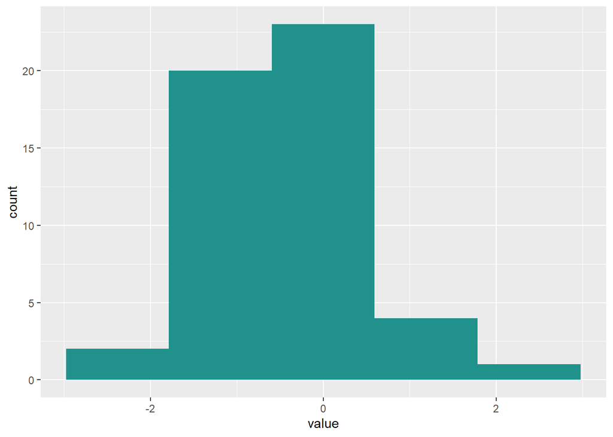

```r
simznorm %>% ggplot(aes(x=value)) + geom_histogram(fill="#21918c", bins=5)
```

- Notice the data series are approximately normally distributed with a mean that is somewhat close to “0” (-0.45) and SD close to “1” (0.89). However, as a random draw from the standard normal distribution, they are not expected to exactly match these parameter values or perfect bell-curved shape. This is especially true when sampling a small number of values from a heterogeneous population.
- We illustrate this sampling variability in the figure below, which was generated by drawing nine samples of n=50 values each from the standard normal distribution (with the same starting seed) and then compiling their histograms into a single figure using the “patchwork” package. For now, do not worry about the code - we will walk you through much of this process soon enough. Instead, just notice how different each of these histograms appear to be despite the fact that they each represent a random sample drawn from the same population (i.e., a standard normal probability distribution).

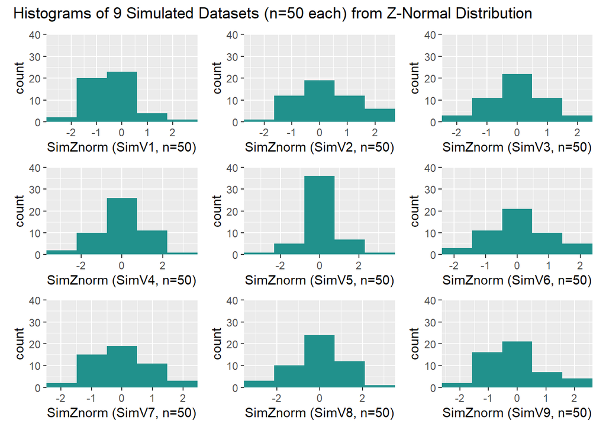

- You may have learned that drawing larger random samples and/or selecting from more homogeneous populations will reduce sampling error and minimize bias in statistical estimation. Again, we illustrate this below, this time by repeating the above procedures but simply changing the `n=50` in the `rnorm()` function to a larger sample size - say, to `n=5000` instead.

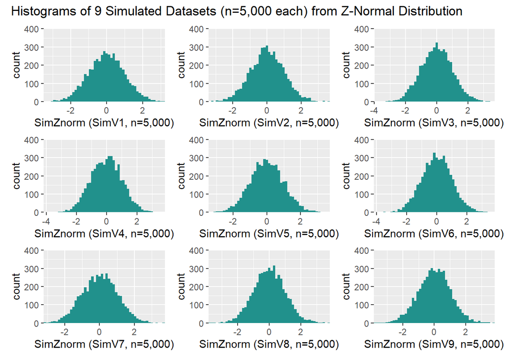

- Notice these samples still vary randomly, but each sample much more closely resembles the standard normal distribution with its iconic bell-shaped curve. In fact, the mean and sd of the first larger (n=5,000) simulated sample also is much closer to standard normal values (mean=0 and sd=1):

*Mean of z-normal simulated sample V1, n=5,000”*

```
## [1] -0.006354696
```

*SD of z-normal simulated sample V1, n=5,000”*

```r
sd(simznorm$V1)
```

```
## [1] 0.991345
```

- Now, let’s compare the plots above from our small (n=50) simulated samples drawn from the standard normal distribution to the plot below of the observed “RobberyRt” distribution from our random sample of states (n=25):

*Sample mean for RobberyRt (n=25 states)*

```
## [1] 99.424
```

*Sample sd for RobberyRt (n=25 states)*

```r
#sample sd of RobberyRt
sd(StatesDataRdm25$RobberyRt)
```

```
## [1] 57.07451
```

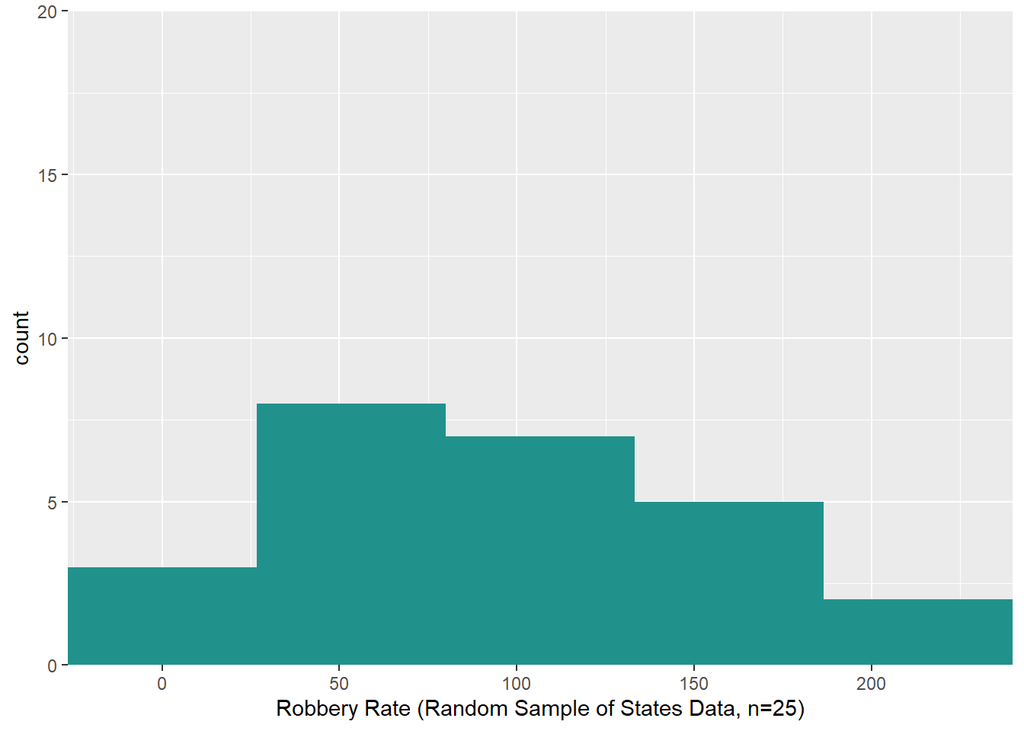

```r
funhist(StatesDataRdm25, RobberyRt, 5, 20, "Robbery Rate (Random Sample of States Data, n=25)")
```

- The “RobberyRt” distribution from our random sample seems like it could have been drawn from a normal probability distribution but, as we would expect, key summary statistics like mean, sd, min, and max values are quite a bit different from the standard or z-normal distribution. So, instead of sampling from the standard normal distribution, let’s try sampling values from a normal probability distribution that more closely matches the empirical distribution of “RobberyRt” values.
2. One way we could start would be to simulate a from a normal distribution, but with specified “mean” and “sd” values estimated from our random sample instead of the standard normal values.
   1. Insert an R chunk,
   2. Since we will be invoking R’s random number generator again, remember to start by setting the random seed to `1234`
   3. After setting the seed, type: `rnorm(n = 50,` then hit enter.
   4. On the next line, type `mean=mean(StatesDataRdm25$RobberyRt),` then hit enter.
   5. On the next line, type `sd=sd(StatesDataRdm25$RobberyRt))` and then run your code.

```r
# simulation of n=25 RobberyRt values from random normal dist
set.seed(1234)
rnorm(n = 50,
      mean = mean(StatesDataRdm25$RobberyRt),
      sd = sd(StatesDataRdm25$RobberyRt))
```

```
##  [1]  30.531317 115.258137 161.317946 -34.455541 123.916080 128.306891
##  [7]  66.621000  68.225256  67.208180  48.625529  72.188462  42.441585
## [13]  55.119691 103.102955 154.186651  93.129510  70.258384  47.417970
## [19]  51.642839 237.306603 107.077019  71.418344  74.279947 125.654841
## [25]  59.830259  16.768418 132.227900  40.999354  98.559989  46.005195
## [31] 162.337090  72.279759  58.933059  70.814943   6.444293  32.782706
## [37] -25.000689  22.887474  82.627323  72.833127 182.153285  38.431743
## [43]  50.604485  83.407580  42.672530  44.146522  36.224360  27.967522
## [49]  69.526768  71.066533
```

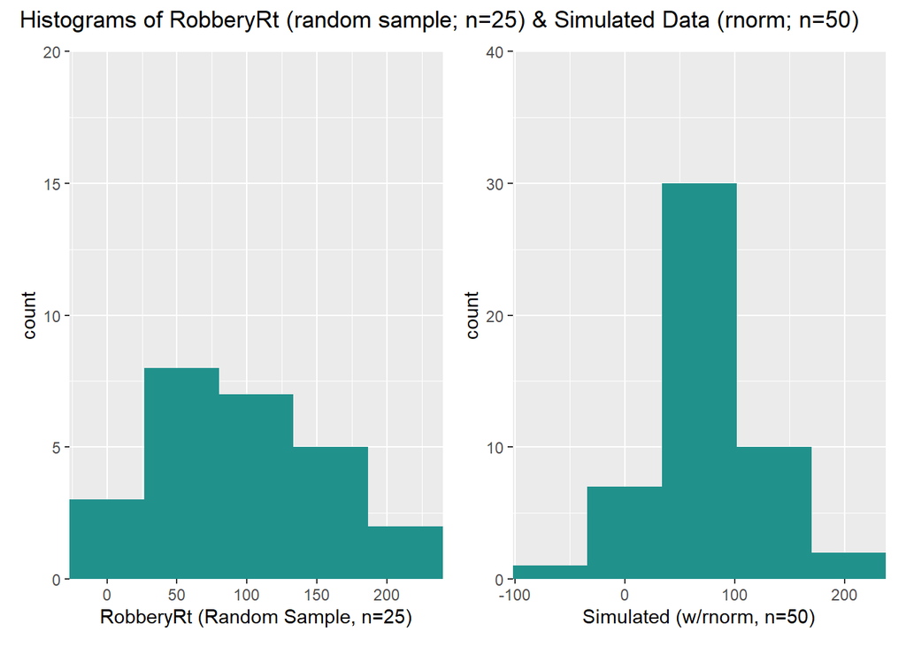

```r
set.seed(1234)
rtruncnorm(n = 50,
           a = 0,
           mean = mean(StatesDataRdm25$RobberyRt),
           sd = sd(StatesDataRdm25$RobberyRt))
```

```
##  [1]  30.531317 115.258137 161.317946 123.916080 128.306891  66.621000
##  [7]  68.225256  67.208180  48.625529  72.188462  42.441585  55.119691
## [13] 103.102955 154.186651  93.129510  70.258384  47.417970  51.642839
## [19] 237.306603 107.077019  71.418344  74.279947 125.654841  59.830259
## [25]  16.768418 132.227900  40.999354  98.559989  46.005195 162.337090
## [31]  72.279759  58.933059  70.814943   6.444293  32.782706  22.887474
## [37]  82.627323  72.833127 182.153285  38.431743  50.604485  83.407580
## [43]  42.672530  44.146522  36.224360  27.967522  69.526768  71.066533
## [49]  66.202303  36.134671
```

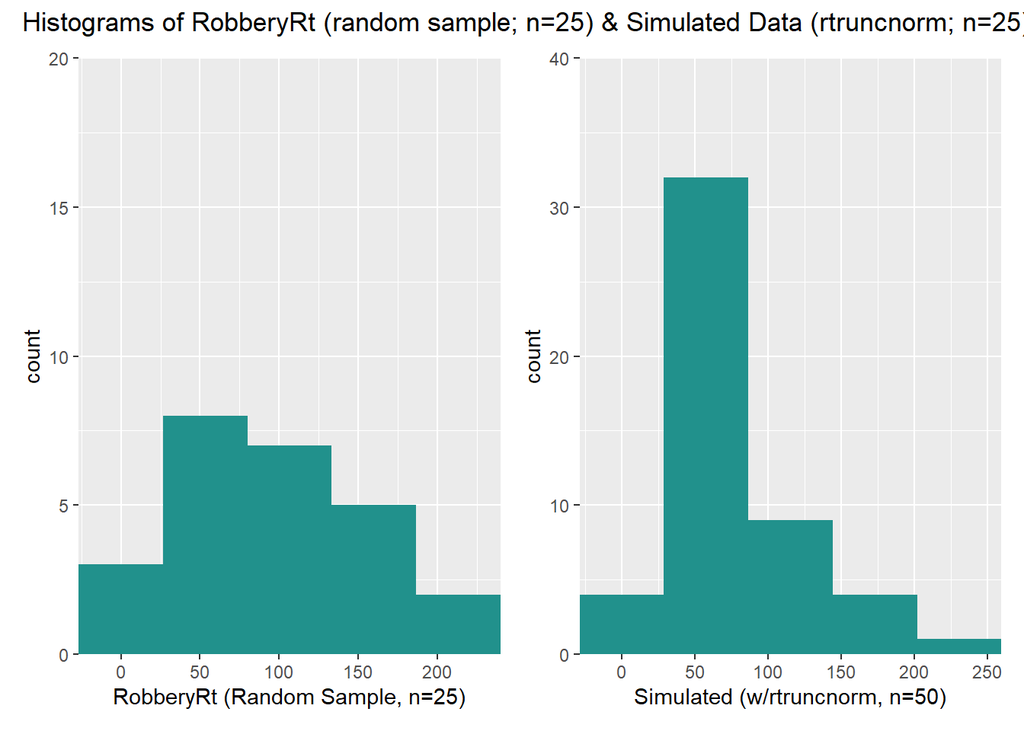

- Before you learn to replicate this simulation process multiple times and create your own patchwork plots, let’s consider one alternative probability distribution - the uniform or “flat” distribution. In a [uniform distribution](https://www.statology.org/uniform-distribution-r/), the probability of selecting any one value between a specified minimum and maximum limit is equal to the probability of selecting any other value. Put differently, every value within the set limits of a uniform distribution is equally likely to be chosen at random.
- Due to this equal probability feature, a uniform distribution generates random samples that, over the long run (i.e., with large samples), resemble uniform or “flat” distributions. Contrast this shape with the peaked (rather than flat) standard normal distribution, where the probability of selecting “0” (i.e., the mean) is higher than that of any other value in the distribution and where the probability of selecting any given value near “0” is much higher than the probability of selecting any given value that is multiple standard deviations away from the mean of “0”.